# My Visual Data Story

STATS220 Project 4

Alistair Wong

## Introduction

Over the last couple of climbing sessions I logged the grades, attempts, whether I topped(completed) the climbed or not, the colour, style and type of wall.

The purpose of this investigation is to find out my current skill level and what types of climbs I am better or worse at.

## Climbing Sessions

In total I logged 12 climbing sessions, 4 during Project 2 and 8 during the duration of this project. The form that was used recorded the date and time of each log, from this the day of the week was extracted and attempts were sorted by day of week as seen below in the plot.

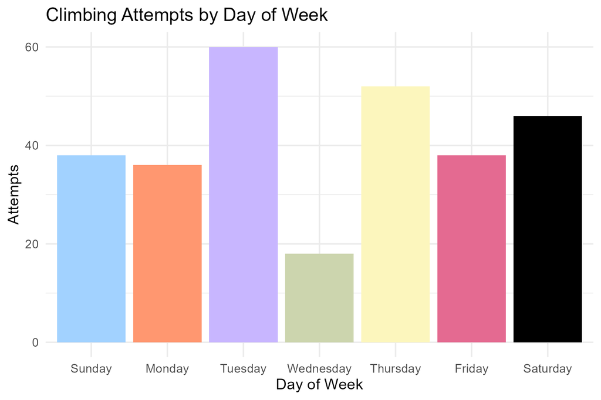

Looking at the plot it seems that I climb the most on Tuesday and the least on Wednesdays. Tuesday has 60 attempts and Wednesday having 18 attempts, about one third the attempts of Tuesday. This Plot is interesting to see as Wednesday is the day that I work and after work there is not a lot of time after to climb so that it makes sense that, that is when I have the least attempts.

## Attempts by Grade

For the following plots only the most recent sessions were used as these contained data about the style of climbing and wall type that was not previously included

There were 163 total attempts over 7 sessions averaging 23 attempts per session and 9 climbs per session (rounded down). Below is a plot of attempts by each grade from 1 to 8. Since this plot was quite spread out I decided to separate this into two different plots, the first one ranging from V1-4 and the second covering V5-8.

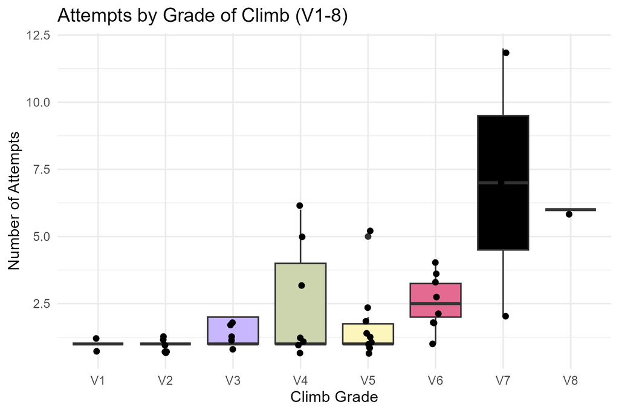

## Attempts by Grade V1 to V4

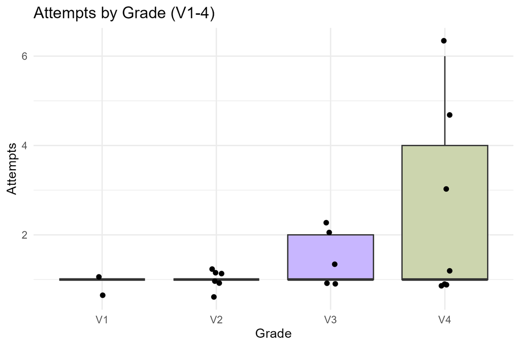

Each climb in V1 and V2 had only 1 attempt except for 1 at V2, this is because I topped the climb on the first try and so there were no further attempts.

V4 has an average of 2.4 attempts with the most attempts at 6. This was a dynamic slab problem which required accuracy and trial and error, so the 6 attempts make sense.

## Attempts by Grade V5 to V8

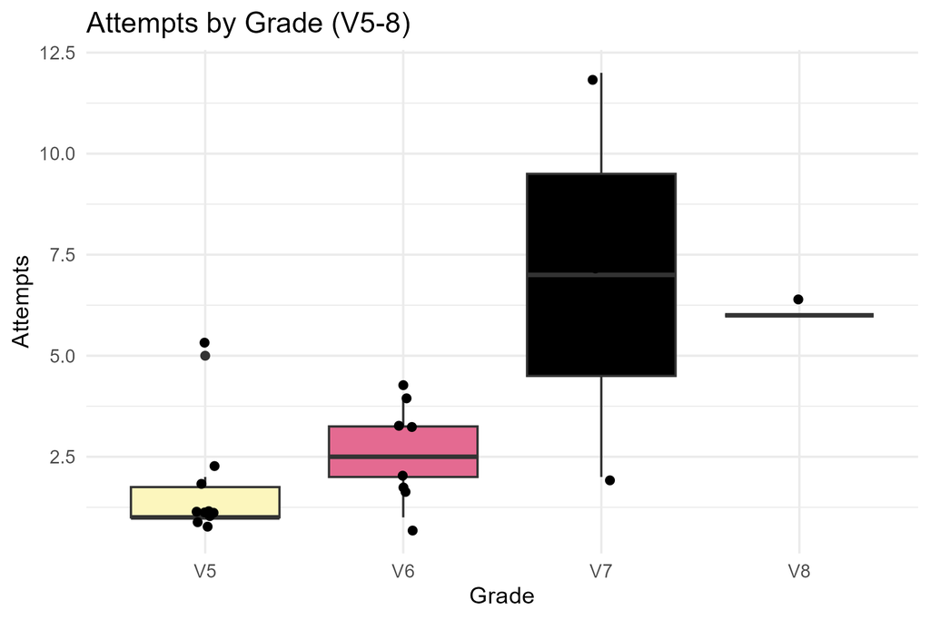

## Grade Success

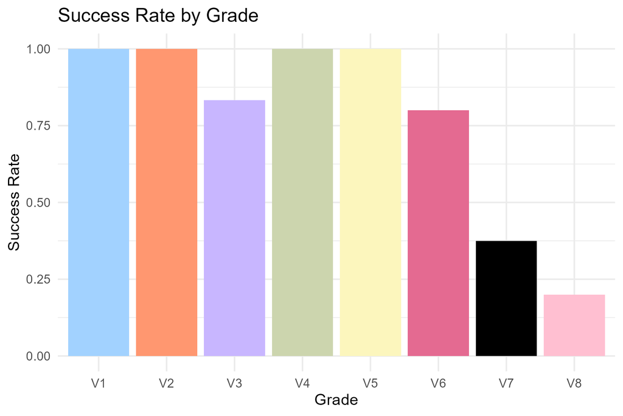

Looking at the plot V1 V2, V4, and V5 have 100% success rate which is expected as these are the lower levels. V3 has a slightly lower success rate at around ~85%, this is only due to one climb where I gave up after 1 attempt. At V6 this starts to lower down to 80% this becomes the limit on where I am able to ‘flash’ a boulder, or get it first try. At V7 the chance that I top a boulder decreases to about 37% and at V8 this goes down to about 20%.

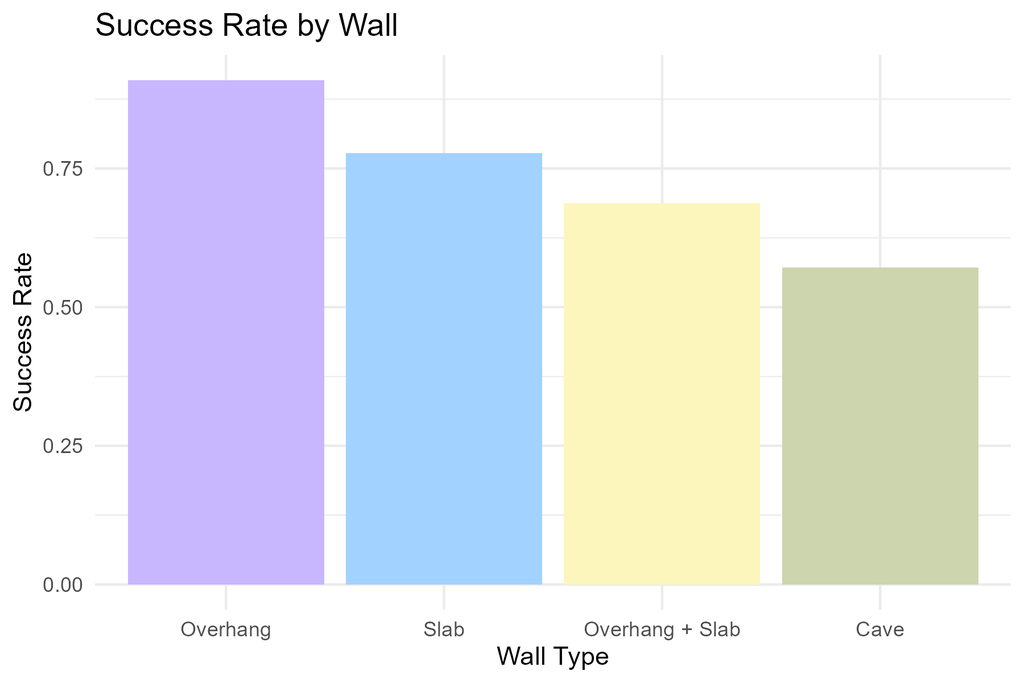

From the plot the I was most successful on the Overhang wall followed by Slab, Overhang + Slab then Cave. Cave I expected to be the lowest as this is my least favourite type of wall. However what was surprising was that the most successful type of wall was overhang and not slab or the combination of the two. It seems that I am better at overhang climbs than I thought and as expected not very good at cave climbing.